# Life, Moods, Productivity, and Macbook Usage

Helen Mary Labao-Barrameda

11/18/2018

## Executive Summary

The bullet journal method of logging everyday habits combined with a granular analysis of my personal activity in my Macbook tries to get a more data-driven idea of what affects my productivity in using my Macbook.

This exploratory report mainly aims to shed light on some questions such as: where does my time go? Am I productive despite my regular struggle with depression? How can I improve my life with better time and energy management?

## Exploratory Data Analyses

## Dependencies

Install library dependencies first to ensure that code will run seamlessly: devtools, ggplot2, dplyr, reshape2, treemapify, ggplotify, ggpubr, and tidyr.

### The Data

It involves 400+ hours on the Macbook (137,000+ rows) analyzed within a 3-month period (FinalExamData_Barrameda_raw.csv). I also encoded a portion of my bullet journal entries that documents my mood, basic nutrition, etc. (BulletJournalData.csv) Each day in the bullet journal has a Self-Care and Mood score.

```r
# load the datasets
mood<-read.csv('BulletJournalData.csv')
macbook<-read.csv('FinalExamData_Barrameda_raw.csv')

head(mood,1)
```

```
##   X...Weekday      Date2 Hours.of.Sleep Exercise Hyper Depressed Stable
## 1    Thursday 11/10/2018              2        0     1         0      0
##   Happy Irritated Reading Studying Working Anxiety GlassesWater
## 1     0         1       1        0       1       1            4
##   VegetableCups Meditate Calligraphy MoodScore SelfCareScore
## 1             0        0           0     -2.25             7
```

```r
head(macbook,1)
```

```
##   Duration       Date    Start      End           Project   Application
## 1      3.4 13/08/2018 10:02:43 10:02:46 Macbook Utilities HandsOffAgent
##    Title Path
## 1 Item-0
```

### Preliminary Data Munging

After some rudimentary inspection of the CSV files in Excel, I began shaping my data in various ways to reveal patterns about my computer usage behavior.

### Super #WorkisLife, Apparently!

More than half of my computer life (311/437 hours) is devoted to my 2 homebased IT and data projects with Cascadeo Corporation and MonetizeMore. No wonder I feel so tired and they don’t want me to quit my job! =D

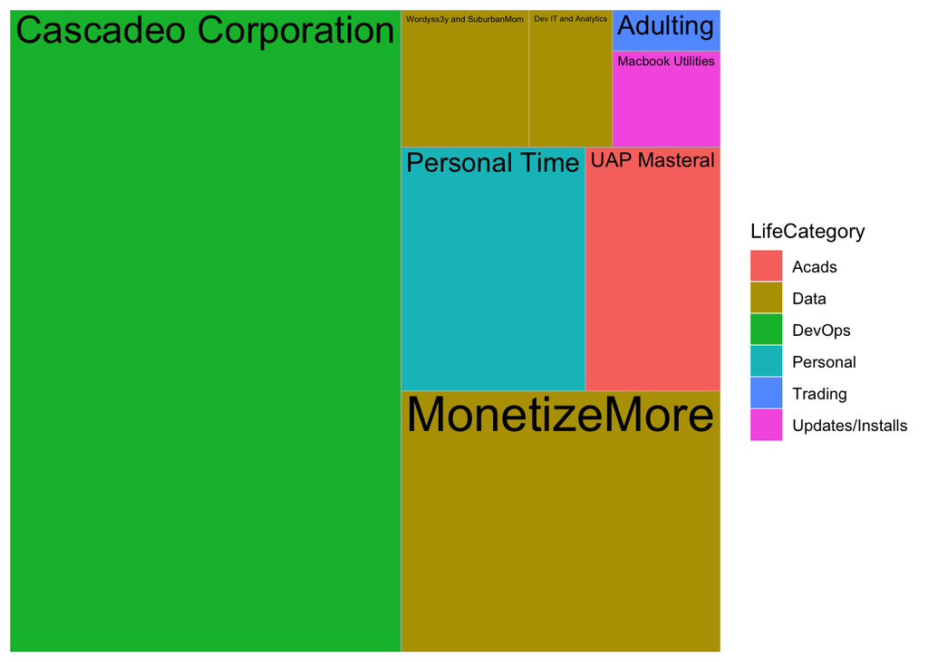

Almost 10 hours is wasted updating, waiting, and installing things. That System76 laptop may be a justifiable wish for my next birthday, after all.

## It’s Not a Very Manic Monday!

The Timing app I used captures 1 log entry for each key stroke I make on my Mac. I analyzed the frequency of keystrokes per weekday to see when are my most hyper days. Why is my Sunday computer activity like this?!? (Well, it’s Sunday now…) On the 10% of actual computer leisure, I identified my most favored apps.

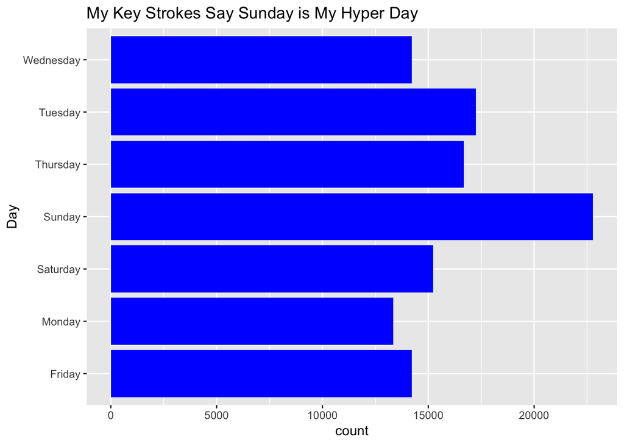

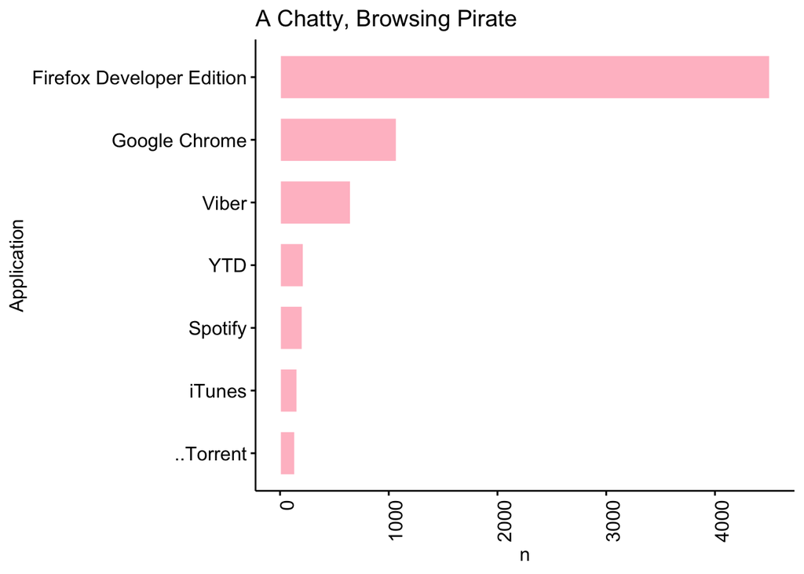

## So, which habit correlates with my productivity and distractibility?

During a subset of the period of observation, I managed to track my personal well-being through my bullet journal for around 3 weeks.

### Self-Care vs Mood

The 3-week data is simply not enough to correlate mood to self-caring.

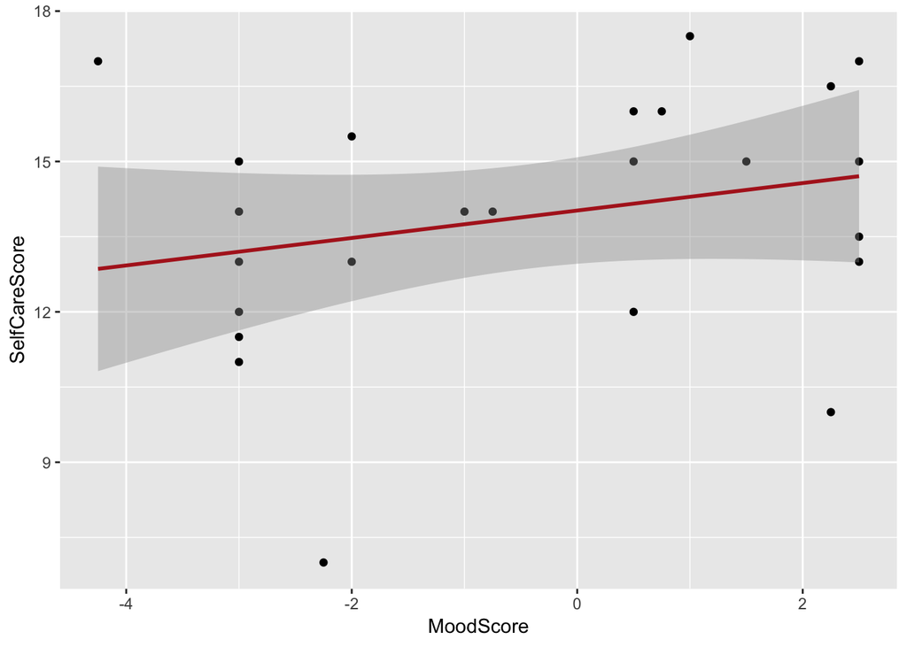

## Links and References

- StackOverflow for R Noobs =D
- The Bullet Journal Method - https://bulletjournal.com/
- The 80/20 Principle: The Secret to Achieving More with Less by Richard Koch (thanks to Mr. Alexander Libranza for lending me the book)
- Time Auditing Concept - https://diggitymarketing.com/time-management-guide/
- Treemap Tutorial - http://mlbernauer.github.io/R/20150309_treemaps_with_ggplot2.html